# Calculus Exploration

Brenna Kokosenski

The purpose of this project is to determine the relationship between fall calculus enrollment and spring calculus enrollment within a given academic year.

Skills used: Visualizing data using a scatterplot, manipulating data using dplyr, pivot_wider

##Load Packages

```r
library(tidyverse)
library(janitor)
```

##Read Data

```r
library(readr)
df1 <- read_csv("CU_ACAD_DEPT_WHEN_OFF_ENRL_22740.csv",
    skip = 1) %>% clean_names()
```

```
## * Term -> Term...7
## * Term -> Term...8
```

## Data manipulation

Filter the data to only the course title, section number, component, course id, the term,and total enrollment

```r
df2 <- df1 %>%
  #filter to only calculus I and II lecture sections
  filter(title=="Calculus I"|title=="Calculus II",component=="LEC") %>%
  #group by course title ans term
group_by(title,term_8)%>%
  #select only the desired variables
  select(title,section,component,course_id,term_8,tot_enrl) %>%
  #arrange based on term
  arrange(term_8)
```

Filter to only Calculus 1 and 2, summarize enrollment of all sections of a given course in the given term, then arrange by term.

```r
df3 <- df2 %>%
  filter(title=="Calculus I"|title=="Calculus II",component=="LEC") %>%
  group_by(title,term_8)%>%
  select(title,section, course_id,term_8,tot_enrl)%>%
  summarize(sum_enroll = sum(tot_enrl)) %>%
  arrange(term_8)
```

Separate the column that displays term in season and year into two separate columns, then filter for only the fall and spring terms to remove data from the summer terms

```r
df4 <- df3 %>%
  separate(term_8,c("term","year"), sep=" ",convert=TRUE)%>%
  #filter to only fall and spring term data
  filter(term== "Fall"| term=="Spring")
```

Mutate the year column to see only the last two numbers of the year (14 instead of 2014, for example). Create a column that represents the academic year associated with each term

```r
df5 <- df4 %>%
  mutate(year=(year-2000)) %>%
  mutate(academic_year=case_when(term=="Fall"~str_c(year, "-", year+1),
  term=="Spring" ~ str_c(year-1, "-", year)))
```

“Rotate” the data table so the variables are academic year, calc 1 fall, calc 2 fall, calc 1 spring, and calc 2 spring. Create a graph of spring calc 2 enrollment versus fall calc 1 enrollment

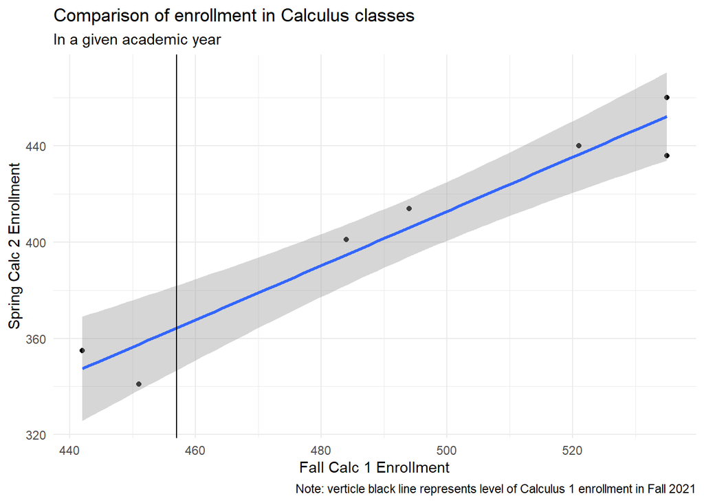

```r
df6 <- df5 %>%
  pivot_wider(academic_year, names_from = c(title,term), values_from = sum_enroll)%>%
  clean_names() %>%
  #account for sections 1&3 being counted twice in Spring 2020
  mutate(calculus_ii_spring=case_when(academic_year=="19-20"~ (calculus_ii_spring-74-52),
                   academic_year!="19-20"~ (calculus_ii_spring))) %>%
arrange(academic_year)


df6 %>%
filter(calculus_ii_spring>0)%>%
  ggplot(aes(x=calculus_i_fall,
             y= calculus_ii_spring))+
  geom_point()+
  geom_smooth(method=lm)+
  geom_vline(xintercept=tail(df6$calculus_i_fall,1))+
  theme_minimal()+
  labs(
    x = "Fall Calc 1 Enrollment",
    y = "Spring Calc 2 Enrollment",
    title = "Comparison of enrollment in Calculus classes",
    subtitle= "In a given academic year",
    caption= "Note: verticle black line represents level of Calculus 1 enrollment in Fall 2021")
```

Based on this graph, we expect there will be somewhere between 350 and 385 students enrolled in Calc 2 in the spring of 2022.